# BioMarin Meetup: reshaping, transforming, and joining data in R (exercises)

# Objectives

This document outlines some common data reshaping tasks with `tidyr`. The slides for this presentation are [here](https://mjfrigaard.github.io/data-transformations-joins/Index.html#1)

There is also an accompanying RStudio.Cloud project:

https://rstudio.cloud/project/1941654

Read more about `dplyr` [here](https://dplyr.tidyverse.org/index.html) and [`tidyr`](https://tidyr.tidyverse.org/) on the tidyverse website, or in the [Data Transformation](https://r4ds.had.co.nz/transform.html) chapter of R for Data Science.

## Load packages

`tidyr` is part of the core `tidyverse` packages, so we install and load this meta-package below.

```r
install.packages("tidyverse")
library(tidyverse)
```

## Manging data

We’re going to use some of the `fs` package functions for managing our files and data.

### Folder trees and paths

Check your files and folders with `dir_tree` or `dir_ls`.

```r
fs::dir_tree("..")
```

```
## ..
## ├── data-trans-joins-exercises.Rproj
## └── docs
##     ├── Index.Rmd
##     ├── Index.html
##     ├── code
##     │   └── 01-create-usada-data.R
##     └── data
##         ├── LabData.csv
##         ├── LabProc.csv
##         ├── SmallLabData.csv
##         ├── UsadaBadDates.csv
##         └── UsadaRaw.csv
```

We can also use `dir_ls` to get the paths to print to the screen so we can easily import.

```r
fs::dir_ls("..", recurse = TRUE)
```

```
## ../data-trans-joins-exercises.Rproj ../docs
## ../docs/Index.Rmd                   ../docs/Index.html
## ../docs/code                        ../docs/code/01-create-usada-data.R
## ../docs/data                        ../docs/data/LabData.csv
## ../docs/data/LabProc.csv            ../docs/data/SmallLabData.csv
## ../docs/data/UsadaBadDates.csv      ../docs/data/UsadaRaw.csv
```

### Metadata

`fs` also gives us the metadata of any folder we have access to. This can come in handy if we’re looking for a specific version of a file, or a file that was created at a specific date.

```r
fs::dir_info("data", all = TRUE) %>%
    dplyr::arrange(desc(modification_time))
```

| path | type | size | permissions | modification_time | user | group | device_id | hard_links | special_device_id | inode | block_size | blocks | flags | generation | access_time | change_time | birth_time |
| --- | --- | --- | --- | --- | --- | --- | --- | --- | --- | --- | --- | --- | --- | --- | --- | --- | --- |
| data/UsadaBadDates.csv | file | 3.13K | rw-rw-rw- | 2020-11-20 09:04:03 | mjfrigaard | staff | 16777223 | 1 | 0 | 12934051131 | 4096 | 8 | 0 | 0 | 2020-11-20 12:56:57 | 2020-11-20 09:04:03 | 2020-11-20 09:04:03 |
| data/UsadaRaw.csv | file | 81.61K | rw-rw-rw- | 2020-11-20 09:04:03 | mjfrigaard | staff | 16777223 | 1 | 0 | 12934050995 | 4096 | 256 | 0 | 0 | 2020-11-20 12:56:57 | 2020-11-20 09:04:03 | 2020-11-20 09:03:06 |
| data/LabProc.csv | file | 164 | rw-rw-rw- | 2020-11-20 08:19:03 | mjfrigaard | staff | 16777223 | 1 | 0 | 12934044652 | 4096 | 8 | 0 | 0 | 2020-11-20 12:53:52 | 2020-11-20 08:19:03 | 2020-11-20 08:13:56 |
| data/SmallLabData.csv | file | 93 | rw-rw-rw- | 2020-11-20 07:58:48 | mjfrigaard | staff | 16777223 | 1 | 0 | 12934035994 | 4096 | 8 | 0 | 0 | 2020-11-20 12:56:57 | 2020-11-20 07:58:48 | 2020-11-20 07:56:48 |
| data/LabData.csv | file | 139 | rw-rw-rw- | 2020-11-20 07:50:05 | mjfrigaard | staff | 16777223 | 1 | 0 | 12934035102 | 4096 | 8 | 0 | 0 | 2020-11-20 12:53:52 | 2020-11-20 07:50:05 | 2020-11-20 07:50:05 |

For example, lets look for the largest `file` in the `data` folder.

```r
fs::dir_info("data", all = TRUE) %>%
    filter(type == "file") %>%
    arrange(desc(size)) %>%
    select(path, size) %>%
    slice(1)
```

| path | size |
| --- | --- |
| data/UsadaRaw.csv | 81.61K |

### Import multiple files

Lets import all the `Lab` data files in `data` using `fs` and `purrr`.

```r
fs::dir_ls(path = "data", regexp = "Lab") %>%
    purrr::map_dfr(read_csv, .id = "source") -> AllLabs
AllLabs
```

| source | lab | value | ref | visit | lab_proc |
| --- | --- | --- | --- | --- | --- |
| data/LabData.csv | Albumin | 3.5, 4.2, 5.0 | 3.4 - 5.4 g/dL |  | NA |
| data/LabData.csv | Potassium, Whole Blood | 1.7, 4.3 | >6.5-7.0 mmol/L |  | NA |
| data/LabData.csv | % Hemoglobin A1c | 4.1, 4.8 | 6.50% |  | NA |
| data/LabProc.csv | NA | NA | NA | 2020-10-01 | Albumin 3.4 g/dL; Potassium 3.8 mmol/L; A1c 4.8 % |
| data/LabProc.csv | NA | NA | NA | 2020-10-10 | Albumin 41 g/dL; A1c 5.0 % |
| data/LabProc.csv | NA | NA | NA | 2020-10-20 | Albumin 4.8 g/dL; Potassium 2.2 mmol/L |
| data/SmallLabData.csv | Albumin | NA | 3.4-5.4 g/dL |  | NA |
| data/SmallLabData.csv | Potassium, Whole Blood | NA | 6.5-7.0 mmol/L |  | NA |
| data/SmallLabData.csv | % Hemoglobin A1c | NA | 6.50 % |  | NA |

## `separate()`

This allows us to split columns apart into multiple variables.

### `separate` ex 1

Take a look at `SmallLabData` below (we’ve used some `dplyr` and the `janitor::remove_empty()` function to get `SmallLabData` from `AllLabs`.

```r
AllLabs %>%
    filter(source == "data/SmallLabData.csv") %>%
    select(-source) %>%
    janitor::remove_empty() -> SmallLabData
SmallLabData
```

| lab | ref |
| --- | --- |
| Albumin | 3.4-5.4 g/dL |
| Potassium, Whole Blood | 6.5-7.0 mmol/L |
| % Hemoglobin A1c | 6.50 % |

Separate `ref` into `ref_value` and `ref_units`

```r
SmallLabData %>%
    separate(col = ___, into = c("_______", "_______"), sep = " ")
```

### `separate` sol 1

```r
SmallLabData %>%
    separate(col = ref, into = c("ref_value", "ref_units"), sep = " ")
```

| lab | ref_value | ref_units |
| --- | --- | --- |
| Albumin | 3.4-5.4 | g/dL |
| Potassium, Whole Blood | 6.5-7.0 | mmol/L |
| % Hemoglobin A1c | 6.50 | % |

## `separate_rows()`

`separate_rows()` is similar to `separate()`, but drops the values down the rows. This is commonly used when we have more than one value in each column.

Take a look at `LabData` below.

```r
AllLabs %>%
    filter(source == "data/LabData.csv") %>%
    select(-source) %>%
    janitor::remove_empty() -> LabData

 LabData
```

| lab | value | ref |
| --- | --- | --- |
| Albumin | 3.5, 4.2, 5.0 | 3.4 - 5.4 g/dL |
| Potassium, Whole Blood | 1.7, 4.3 | >6.5-7.0 mmol/L |
| % Hemoglobin A1c | 4.1, 4.8 | 6.50% |

### `separate_rows` ex 1

Put all the `value`s into their own cell, and make sure the new variable is numeric.

```r
LabData %>%
  separate_rows(_____, sep = _____, convert = TRUE)
```

### `separate_rows` sol 1

Note the `convert` argument to make `value` numeric.

```r
LabData %>%
  separate_rows(value, sep = ", ", convert = TRUE)
```

| lab | value | ref |
| --- | --- | --- |
| Albumin | 3.5 | 3.4 - 5.4 g/dL |
| Albumin | 4.2 | 3.4 - 5.4 g/dL |
| Albumin | 5.0 | 3.4 - 5.4 g/dL |
| Potassium, Whole Blood | 1.7 | >6.5-7.0 mmol/L |
| Potassium, Whole Blood | 4.3 | >6.5-7.0 mmol/L |
| % Hemoglobin A1c | 4.1 | 6.50% |
| % Hemoglobin A1c | 4.8 | 6.50% |

## `unite()`

Just like `separate`/`separate_rows` allows us to split up columns, `unite()` lets us stick them back together!

Take a look at `LabProc`.

```r
AllLabs %>%
    filter(source == "data/LabProc.csv") %>%
    select(-source) %>%
    janitor::remove_empty() -> LabProc
LabProc
```

| visit | lab_proc |
| --- | --- |
| 2020-10-01 | Albumin 3.4 g/dL; Potassium 3.8 mmol/L; A1c 4.8 % |
| 2020-10-10 | Albumin 41 g/dL; A1c 5.0 % |
| 2020-10-20 | Albumin 4.8 g/dL; Potassium 2.2 mmol/L |

### `unite` ex 1

Separate the labs from each other, and drop them down the rows.

```r
LabProc %>%
    separate_rows(lab_proc, sep = "___")
```

### `unite` ex 2

Put `lab`, `value`, and `units` in to their own columns.

```r
LabProc %>%
    separate_rows(lab_proc, sep = "___") %>%
    separate(col = lab_proc,into = c('__', '_____', '_____'),
           sep = " ", convert = ____)
```

### `unite` ex 3

Unite `lab`, `value` and `units` into `lab_name` (don’t remove the previous columns with `remove = FALSE`).

```r
LabProc %>%
    separate_rows(lab_proc, sep = "___") %>%
    separate(col = lab_proc,into = c('__', '_____', '_____'),
           sep = " ", convert = ____)
    unite(col = "_______", lab:units, sep = " ", remove = _____)
```

### `unite` sol 1

Separate the labs from each other, and drop them down the rows.

```r
LabProc %>%
     separate_rows(lab_proc, sep = "; ")
```

| visit | lab_proc |
| --- | --- |
| 2020-10-01 | Albumin 3.4 g/dL |
| 2020-10-01 | Potassium 3.8 mmol/L |
| 2020-10-01 | A1c 4.8 % |
| 2020-10-10 | Albumin 41 g/dL |
| 2020-10-10 | A1c 5.0 % |
| 2020-10-20 | Albumin 4.8 g/dL |
| 2020-10-20 | Potassium 2.2 mmol/L |

### `unite` sol 2

Put `lab`, `value`, and `units` in to their own columns.

```r
LabProc %>%
     separate_rows(lab_proc, sep = "; ") %>%
     separate(col = lab_proc,into = c('lab', 'value', 'units'),
            sep = " ", convert = TRUE)
```

| visit | lab | value | units |
| --- | --- | --- | --- |
| 2020-10-01 | Albumin | 3.4 | g/dL |
| 2020-10-01 | Potassium | 3.8 | mmol/L |
| 2020-10-01 | A1c | 4.8 | % |
| 2020-10-10 | Albumin | 41.0 | g/dL |
| 2020-10-10 | A1c | 5.0 | % |
| 2020-10-20 | Albumin | 4.8 | g/dL |
| 2020-10-20 | Potassium | 2.2 | mmol/L |

### `unite` sol 3

Unite `lab`, `value` and `units` into `lab_name` (don’t remove the previous columns with `remove = FALSE`).

```r
LabProc %>%
     separate_rows(lab_proc, sep = "; ") %>%
     separate(col = lab_proc,into = c('lab', 'value', 'units'),
            sep = " ", convert = TRUE) %>%
     unite(col = "lab_name", lab:units, sep = " ", remove = FALSE)
```

| visit | lab_name | lab | value | units |
| --- | --- | --- | --- | --- |
| 2020-10-01 | Albumin 3.4 g/dL | Albumin | 3.4 | g/dL |
| 2020-10-01 | Potassium 3.8 mmol/L | Potassium | 3.8 | mmol/L |
| 2020-10-01 | A1c 4.8 % | A1c | 4.8 | % |
| 2020-10-10 | Albumin 41 g/dL | Albumin | 41.0 | g/dL |
| 2020-10-10 | A1c 5 % | A1c | 5.0 | % |
| 2020-10-20 | Albumin 4.8 g/dL | Albumin | 4.8 | g/dL |
| 2020-10-20 | Potassium 2.2 mmol/L | Potassium | 2.2 | mmol/L |

## `unnest()` use case

`unnest()` deals with nested data, which can be complicated to explain, so we’ll use an example. Run the code below to download data from the [Anti-Doping Agency Sanction database](https://www.usada.org/news/sanctions/).

```r
source("code/01-create-usada-data.R")
```

These data have two dates (`original` and `updated`) in a single column (`sanction_announced`). **We only want `updated` dates in their own columns.**

```r
UsadaBadDates
```

| athlete | sanction_announced | sport | substance_reason | sanction_terms |
| --- | --- | --- | --- | --- |
| fischbach, dylan | original: 12/18/2015; updated: 04/11/2016 | paralympic basketball | non-analytical: refusal to submit to sample collection | 2-year suspension - loss of results - additional results disqualified |
| trafeh, mohamed | original: 12/18/2014; updated: 08/25/2015 | track and field | non-analytical: use and possession (epo), and evading sample collection | 4-year suspension - loss of results |
| lea, robert | original: 12/17/2015; updated: 02/25/2016 | cycling | noroxycodone | 6-month suspension - loss of results |
| young, jerome | original: 11/10/2004; updated: 06/17/2008 | track and field | erythropoietin (epo) and non-analytical: use (epo & hgh) | lifetime suspension - loss of results |
| hay, amy | original: 10/31/2017; updated: 12/16/2019 | weightlifting | ostarine | 2-year suspension; loss of results; sanction reduced; unretired - eligible to compete starting 07/25/2020 |
| hunter, adam | original: 10/28/2016; updated: 09/26/2018 | mixed martial arts | tamoxifen; boldenone, methandienone, drostanolone, and clenbuterol | 2-year suspension - loss of results - additional loss of results |
| tovar, oscar | original: 10/28/2015; updated: 10/04/2016 | cycling | androgenic anabolic steroid | 2-year suspension - loss of results - additional results disqualified |
| dotti, juan pablo | original: 10/20/2011; updated: 06/05/2013 | cycling | androgenic anabolic steroid & amphetamine | 2-year suspension - loss of results; \n2-year suspension restarted - loss of results |
| murdock, vince | original: 09/05/2019; updated: 08/26/2020 | mixed martial arts | gw1516 | 20-month suspension - sanction reduced |
| thomas, tammy | original: 08/30/2002; updated: 02/13/2017 | cycling | norbolethone | lifetime ban - loss of results - sanction reduced |

[output cut: 10 more lines]

### `str_split`

Use the `stringr` package’s `str_split` function to split the bad dates on the `"updated"` pattern.

```r
UsadaBadDates %>%
        dplyr::mutate(sanction_dates =
    # 1) split this on the "updated" pattern
             stringr::str_split(string = sanction_announced,
                                pattern = "updated")) %>%
    # only return what we're interested in
    dplyr::select(athlete, sanction_announced, sanction_dates)
```

| athlete | sanction_announced | sanction_dates |
| --- | --- | --- |
| fischbach, dylan | original: 12/18/2015; updated: 04/11/2016 |  |
| trafeh, mohamed | original: 12/18/2014; updated: 08/25/2015 |  |
| lea, robert | original: 12/17/2015; updated: 02/25/2016 |  |
| young, jerome | original: 11/10/2004; updated: 06/17/2008 |  |
| hay, amy | original: 10/31/2017; updated: 12/16/2019 |  |
| hunter, adam | original: 10/28/2016; updated: 09/26/2018 |  |
| tovar, oscar | original: 10/28/2015; updated: 10/04/2016 |  |
| dotti, juan pablo | original: 10/20/2011; updated: 06/05/2013 |  |
| murdock, vince | original: 09/05/2019; updated: 08/26/2020 |  |
| thomas, tammy | original: 08/30/2002; updated: 02/13/2017 |  |

[output cut: 10 more lines]

### Nested data

This creates a nested column (`sanction_dates`), which we can deal with by `unnest()`ing it. Let’s take a better look with `listviewer` (but only look at `athlete` and `sanction_dates`).

```r
library(listviewer)
UsadaBadDates %>%
        dplyr::mutate(sanction_dates =
    # 1) split this on the "updated" pattern
             stringr::str_split(string = sanction_announced,
                                pattern = "updated")) %>%
    # only return what we're interested in
    dplyr::select(athlete, sanction_dates) %>%
    listviewer::jsonedit(mode = "view")
```

[interactive chart not shown]

### `unnest`

After unnesting, we can see the dates have been repeated down the rows (like `separate_rows()`).

```r
UsadaBadDates %>%
        dplyr::mutate(sanction_dates =
    # 1) split this on the "updated" pattern
             stringr::str_split(string = sanction_announced,
                                pattern = "updated")) %>%
    # convert the output from split into multiple rows
        tidyr::unnest(sanction_dates) %>%
    # check this to see what is happening
    dplyr::select(athlete, sanction_announced, sanction_dates)
```

| athlete | sanction_announced | sanction_dates |
| --- | --- | --- |
| fischbach, dylan | original: 12/18/2015; updated: 04/11/2016 | original: 12/18/2015; |
| fischbach, dylan | original: 12/18/2015; updated: 04/11/2016 | : 04/11/2016 |
| trafeh, mohamed | original: 12/18/2014; updated: 08/25/2015 | original: 12/18/2014; |
| trafeh, mohamed | original: 12/18/2014; updated: 08/25/2015 | : 08/25/2015 |
| lea, robert | original: 12/17/2015; updated: 02/25/2016 | original: 12/17/2015; |
| lea, robert | original: 12/17/2015; updated: 02/25/2016 | : 02/25/2016 |
| young, jerome | original: 11/10/2004; updated: 06/17/2008 | original: 11/10/2004; |
| young, jerome | original: 11/10/2004; updated: 06/17/2008 | : 06/17/2008 |
| hay, amy | original: 10/31/2017; updated: 12/16/2019 | original: 10/31/2017; |
| hay, amy | original: 10/31/2017; updated: 12/16/2019 | : 12/16/2019 |

[output cut: 30 more lines]

### `filter`

We can see all of the updated dates are on a new line, and the original dates still contain the text. Now I can filter out the rows with an original date (because I am only interested in the updated dates).

```r
UsadaBadDates %>%
        dplyr::mutate(sanction_dates =
    # 1) split this on the "updated" pattern
             stringr::str_split(string = sanction_announced,
                                pattern = "updated")) %>%
    # 2) convert the output from split into multiple rows
        tidyr::unnest(sanction_dates) %>%

    # 3) remove the "original" dates
        dplyr::filter(!str_detect(string = sanction_dates,
                                  pattern = "original")) %>%
    # check this to see what is happening
    dplyr::select(athlete, sanction_announced, sanction_dates)
```

| athlete | sanction_announced | sanction_dates |
| --- | --- | --- |
| fischbach, dylan | original: 12/18/2015; updated: 04/11/2016 | : 04/11/2016 |
| trafeh, mohamed | original: 12/18/2014; updated: 08/25/2015 | : 08/25/2015 |
| lea, robert | original: 12/17/2015; updated: 02/25/2016 | : 02/25/2016 |
| young, jerome | original: 11/10/2004; updated: 06/17/2008 | : 06/17/2008 |
| hay, amy | original: 10/31/2017; updated: 12/16/2019 | : 12/16/2019 |
| hunter, adam | original: 10/28/2016; updated: 09/26/2018 | : 09/26/2018 |
| tovar, oscar | original: 10/28/2015; updated: 10/04/2016 | : 10/04/2016 |
| dotti, juan pablo | original: 10/20/2011; updated: 06/05/2013 | : 06/05/2013 |
| murdock, vince | original: 09/05/2019; updated: 08/26/2020 | : 08/26/2020 |
| thomas, tammy | original: 08/30/2002; updated: 02/13/2017 | : 02/13/2017 |

[output cut: 10 more lines]

### `str_remove_all`

Now I can clean up the updated `sanction_dates` and format it.

```r
UsadaBadDates %>%
        dplyr::mutate(sanction_dates =
    # 1) split this on the "updated" pattern
             stringr::str_split(string = sanction_announced,
                                pattern = "updated")) %>%
    # 2) convert the output from split into multiple rows
        tidyr::unnest(sanction_dates) %>%

    # 3) remove the "original" dates
        dplyr::filter(!str_detect(string = sanction_dates,
                                  pattern = "original")) %>%
    # 4) remove the colon from sanction_dates
        dplyr::mutate(sanction_dates = stringr::str_remove_all(
                                                      string = sanction_dates,
                                                      pattern = ":"),
                      # 5) remove any whitespace
                      sanction_dates = stringr::str_trim(sanction_dates),
                      # 6) format as date
                      sanction_dates = lubridate::mdy(sanction_dates)) %>%
    # check this to see what is happening
    dplyr::select(athlete, sanction_announced, sanction_dates)
```

| athlete | sanction_announced | sanction_dates |
| --- | --- | --- |
| fischbach, dylan | original: 12/18/2015; updated: 04/11/2016 | 2016-04-11 |
| trafeh, mohamed | original: 12/18/2014; updated: 08/25/2015 | 2015-08-25 |
| lea, robert | original: 12/17/2015; updated: 02/25/2016 | 2016-02-25 |
| young, jerome | original: 11/10/2004; updated: 06/17/2008 | 2008-06-17 |
| hay, amy | original: 10/31/2017; updated: 12/16/2019 | 2019-12-16 |
| hunter, adam | original: 10/28/2016; updated: 09/26/2018 | 2018-09-26 |
| tovar, oscar | original: 10/28/2015; updated: 10/04/2016 | 2016-10-04 |
| dotti, juan pablo | original: 10/20/2011; updated: 06/05/2013 | 2013-06-05 |
| murdock, vince | original: 09/05/2019; updated: 08/26/2020 | 2020-08-26 |
| thomas, tammy | original: 08/30/2002; updated: 02/13/2017 | 2017-02-13 |

[output cut: 10 more lines]

### `ggplot2`

*How far can this pipe go??*

Well, when the data are arranged in the way we want, we can test it with a visualization to check the number of sanctions per sport with bad dates.

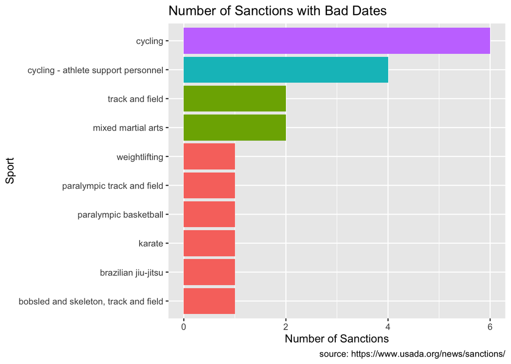

```r
UsadaBadDates %>%
        dplyr::mutate(sanction_dates =
    # 1) split this on the "updated" pattern
             stringr::str_split(string = sanction_announced,
                                pattern = "updated")) %>%
    # 2) convert the output from split into multiple rows
        tidyr::unnest(sanction_dates) %>%

    # 3) remove the "original" dates
        dplyr::filter(!str_detect(string = sanction_dates,
                                  pattern = "original")) %>%
    # 4) remove the colon from sanction_dates
        dplyr::mutate(sanction_dates = stringr::str_remove_all(
                                                      string = sanction_dates,
                                                      pattern = ":"),
                      # 5) remove any whitespace
                      sanction_dates = stringr::str_trim(sanction_dates),
                      # 6) format as date
                      sanction_dates = lubridate::mdy(sanction_dates)) %>%
    # count by sport
    dplyr::count(sport, sort = TRUE) %>%
    # rename n
    rename(`Sport Count` = n,
            Sport = sport) %>%
    ggplot2::ggplot(aes(x = `Sport Count`,
                        y = forcats::fct_reorder(as.factor(Sport), `Sport Count`),
                        fill = as.character(`Sport Count`))) +
    geom_col(show.legend = FALSE) +
    labs(x = "Number of Sanctions", y = "Sport",
         title = "Number of Sanctions with Bad Dates",
         caption = "source: https://www.usada.org/news/sanctions/")
```